# STAT 452 Final Project, Joshua Matni

```r
df <- read.table("data.txt", header = TRUE)
df
```

| X1 | X2 | X3 | X4 | X5 | X6 | X7 | X8 | X9 | X10 | X11 | X12 | X13 | X14 | X15 | Y |
| --- | --- | --- | --- | --- | --- | --- | --- | --- | --- | --- | --- | --- | --- | --- | --- |
| 36 | 27 | 71 | 8.1 | 3.34 | 11.4 | 81.5 | 3243 | 8.8 | 42.6 | 11.7 | 21 | 15 | 59 | 59 | 921.87 |
| 35 | 23 | 72 | 11.1 | 3.14 | 11.0 | 78.8 | 4281 | 3.5 | 50.7 | 14.4 | 8 | 10 | 39 | 57 | 997.88 |
| 44 | 29 | 74 | 10.4 | 3.21 | 9.8 | 81.6 | 4260 | 0.8 | 39.4 | 12.4 | 6 | 6 | 33 | 54 | 962.35 |
| 47 | 45 | 79 | 6.5 | 3.41 | 11.1 | 77.5 | 3125 | 27.1 | 50.2 | 20.6 | 18 | 8 | 24 | 56 | 982.29 |
| 43 | 35 | 77 | 7.6 | 3.44 | 9.6 | 84.6 | 6441 | 24.4 | 43.7 | 14.3 | 43 | 38 | 206 | 55 | 1071.29 |
| 53 | 45 | 80 | 7.7 | 3.45 | 10.2 | 66.8 | 3325 | 38.5 | 43.1 | 25.5 | 30 | 32 | 72 | 54 | 1030.38 |
| 43 | 30 | 74 | 10.9 | 3.23 | 12.1 | 83.9 | 4679 | 3.5 | 49.2 | 11.3 | 21 | 32 | 62 | 56 | 934.70 |
| 45 | 30 | 73 | 9.3 | 3.29 | 10.6 | 86.0 | 2140 | 5.3 | 40.4 | 10.5 | 6 | 4 | 4 | 56 | 899.53 |
| 36 | 24 | 70 | 9.0 | 3.31 | 10.5 | 83.2 | 6582 | 8.1 | 42.5 | 12.6 | 18 | 12 | 37 | 61 | 1001.90 |
| 36 | 27 | 72 | 9.5 | 3.36 | 10.7 | 79.3 | 4213 | 6.7 | 41.0 | 13.2 | 12 | 7 | 20 | 59 | 912.35 |

[output cut: 50 more lines]

# 1. [5 pts] Describe your data. Identify your response variable and predictors.

The dataset contains information on environmental, demographic, and socioeconomic factors that may influence total age-adjusted mortality from all causes, which serves as the response variable (Y) in this analysis.

Response variable: Y (Total age-adjusted mortality from all causes)

Predictors (15): X1 Mean annual precipitation (inches) X2 Mean January temperature (degrees Fahrenheit) X3 Mean July temperature (degrees Fahrenheit) X4 Percent of population over 65 years of age X5 Population per household X6 Median school years completed X7 Percent of housing units that are sound X8 Population per square mile X9 Percent of nonwhite population X10 Percent employment in white-collar jobs X11 Percent of families with income under $3000 X12 Relative pollution potential of hydrocarbons X13 Relative pollution potential of oxide of nitrogen X14 Relative pollution potential of sulfur dioxide X15 Percent relative humidity

# 2. [15 pts] Fit a linear regression model

```r
full_model <- lm(Y ~ ., data = df) # '.' means all other columns
summary(full_model)
```

```
Call:
lm(formula = Y ~ ., data = df)

Residuals:
    Min      1Q  Median      3Q     Max
-68.068 -18.018   0.912  19.224  86.966

Coefficients:
              Estimate Std. Error t value Pr(>|t|)
(Intercept)  1.764e+03  4.373e+02   4.034 0.000215 ***
X1           1.905e+00  9.237e-01   2.063 0.045078 *
X2          -1.938e+00  1.108e+00  -1.748 0.087415 .
X3          -3.100e+00  1.902e+00  -1.630 0.110164
X4          -9.065e+00  8.486e+00  -1.068 0.291246
X5          -1.068e+02  6.978e+01  -1.531 0.132936
X6          -1.716e+01  1.186e+01  -1.447 0.155095
X7          -6.511e-01  1.768e+00  -0.368 0.714397
X8           3.601e-03  4.027e-03   0.894 0.376132
X9           4.460e+00  1.327e+00   3.360 0.001618 **
X10         -1.871e-01  1.662e+00  -0.113 0.910840
X11         -1.674e-01  3.227e+00  -0.052 0.958865
X12         -6.722e-01  4.910e-01  -1.369 0.177980
X13          1.340e+00  1.006e+00   1.333 0.189508
X14          8.626e-02  1.475e-01   0.585 0.561697
X15          1.067e-01  1.169e+00   0.091 0.927690
---
Signif. codes:  0 ‘***’ 0.001 ‘**’ 0.01 ‘*’ 0.05 ‘.’ 0.1 ‘ ’ 1

Residual standard error: 34.93 on 44 degrees of freedom
Multiple R-squared:  0.7649,    Adjusted R-squared:  0.6847
F-statistic: 9.542 on 15 and 44 DF,  p-value: 2.193e-09
```

# 3. [15 pts] Choose the best model using stepwise selection method. (you may use your favorite selection criterion)

```r
# stepwise selection
# "both" allows both forward and backward selection. Will try to add and remove variables at each step
stepwise_model <- step(full_model, direction = "both")
```

```
Start:  AIC=439.79
Y ~ X1 + X2 + X3 + X4 + X5 + X6 + X7 + X8 + X9 + X10 + X11 +
    X12 + X13 + X14 + X15

       Df Sum of Sq   RSS    AIC
- X11   1       3.3 53684 437.79
- X15   1      10.2 53691 437.80
- X10   1      15.5 53696 437.81
- X7    1     165.5 53846 437.97
- X14   1     417.2 54098 438.25
- X8    1     975.3 54656 438.87
- X4    1    1392.2 55073 439.32
<none>              53681 439.79
- X13   1    2166.7 55848 440.16
- X12   1    2286.2 55967 440.29
- X6    1    2553.1 56234 440.58
- X5    1    2859.6 56540 440.90
- X3    1    3242.9 56924 441.31
- X2    1    3728.4 57409 441.82
- X1    1    5190.7 58872 443.33
- X9    1   13774.5 67455 451.49

Step:  AIC=437.79
Y ~ X1 + X2 + X3 + X4 + X5 + X6 + X7 + X8 + X9 + X10 + X12 +
    X13 + X14 + X15

       Df Sum of Sq   RSS    AIC
- X15   1      12.7 53697 435.81
- X10   1      13.4 53698 435.81
- X7    1     215.2 53899 436.03
- X14   1     426.0 54110 436.27
- X8    1    1002.1 54686 436.90
- X4    1    1637.6 55322 437.59
<none>              53684 437.79
- X13   1    2163.4 55848 438.16
- X12   1    2286.6 55971 438.29
- X6    1    2549.9 56234 438.58
- X5    1    2912.2 56596 438.96
- X3    1    3344.1 57028 439.42
+ X11   1       3.3 53681 439.79
```

[output cut: 95 more lines]

```
- X4    1    2590.1 57949 430.38
+ X8    1    1136.5 54223 430.39
+ X14   1     639.2 54720 430.94
+ X11   1      97.3 55262 431.53
+ X10   1      59.2 55300 431.57
+ X7    1      14.3 55345 431.62
+ X15   1       8.0 55351 431.63
- X1    1    5442.5 60802 433.26
- X5    1    5848.9 61208 433.66
- X3    1    6251.9 61611 434.06
- X12   1    9238.5 64598 436.90
- X13   1   10433.8 65793 438.00
- X2    1   11706.0 67065 439.14
- X6    1   12178.8 67538 439.57
- X9    1   25634.1 80993 450.47
```

```r
summary(stepwise_model)
```

```
Call:
lm(formula = Y ~ X1 + X2 + X3 + X4 + X5 + X6 + X9 + X12 + X13,
    data = df)

Residuals:
    Min      1Q  Median      3Q     Max
-71.087 -22.006   0.677  16.883  79.771

Coefficients:
             Estimate Std. Error t value Pr(>|t|)
(Intercept) 1934.0683   333.4988   5.799 4.48e-07 ***
X1             1.8564     0.8373   2.217  0.03119 *
X2            -2.2620     0.6957  -3.252  0.00206 **
X3            -3.3199     1.3971  -2.376  0.02136 *
X4           -10.9202     7.1398  -1.529  0.13245
X5          -137.3881    59.7751  -2.298  0.02576 *
X6           -23.4217     7.0620  -3.317  0.00170 **
X9             4.6623     0.9689   4.812 1.42e-05 ***
X12           -0.9222     0.3192  -2.889  0.00571 **
X13            1.8711     0.6095   3.070  0.00346 **
---
Signif. codes:  0 ‘***’ 0.001 ‘**’ 0.01 ‘*’ 0.05 ‘.’ 0.1 ‘ ’ 1

Residual standard error: 33.27 on 50 degrees of freedom
Multiple R-squared:  0.7575,    Adjusted R-squared:  0.7139
F-statistic: 17.36 on 9 and 50 DF,  p-value: 1.481e-12
```

## Model Selection Using Stepwise Procedure

To select the best model, we used stepwise selection with both forward and backward selection, using AIC as the selection criterion. This approach allows predictors to be added or removed at each step based on how much they improve model fit, as measured by AIC. We began with a full model containing 15 predictors.

The final model selected includes the predictors: X1, X2, X3, X4, X5, X6, X9, X12, and X13. The selection process reduced the AIC from 439.79 to 429.64, indicating an improvement in model fit. This model also achieves an Adjusted R-squared of 0.7139, meaning it explains 71.39% of the variability in the response variable (Y). The residual standard error of the model is 33.27, and the F-statistic indicates that at least one predictor is significantly related to Y (p < 0.05).

We selected this model because it strikes a balance between fit (as seen in the lower AIC) and simplicity (only 9 predictors instead of 15). Most predictors are statistically significant (p < 0.05) except for X4, which had a p-value of 0.13245. Although X4 is not significant, it was retained because removing it did not significantly reduce the AIC.

Based on these metrics, we chose Y ~ X1 + X2 + X3 + X4 + X5 + X6 + X9 + X12 + X13 as the best model. This model has a good balance of simplicity, high explanatory power, and low prediction error.

# 4. [15 pts] Check if there is any outlier.

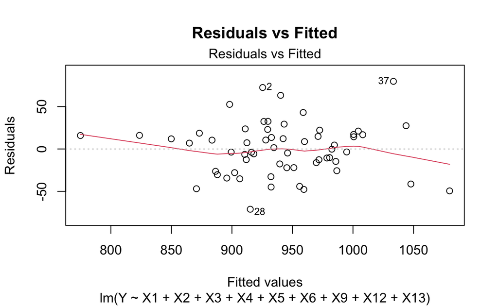

```r
# residuals vs Fitted
plot(stepwise_model, which = 1, main = "Residuals vs Fitted")
```

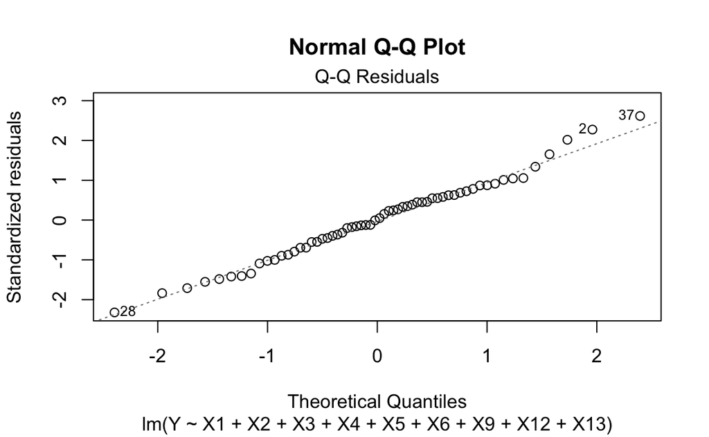

```r
# normal Q-Q Plot
plot(stepwise_model, which = 2, main = "Normal Q-Q Plot")
```

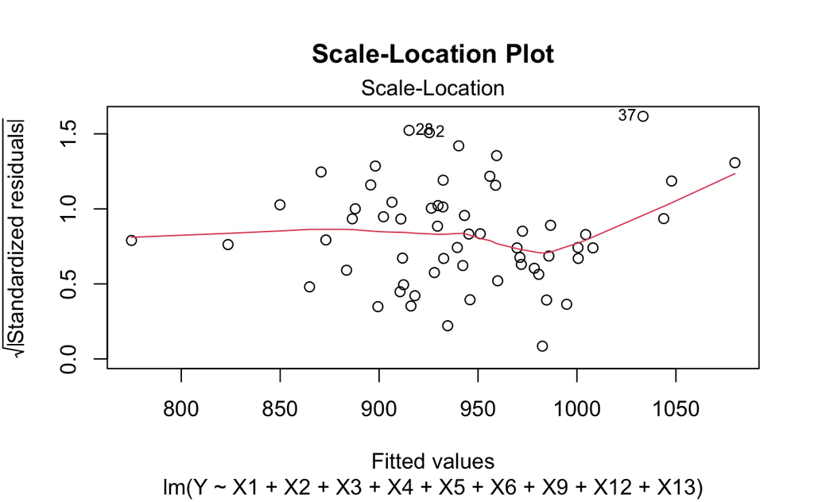

```r
# scale-location plot
plot(stepwise_model, which = 3, main = "Scale-Location Plot")
```

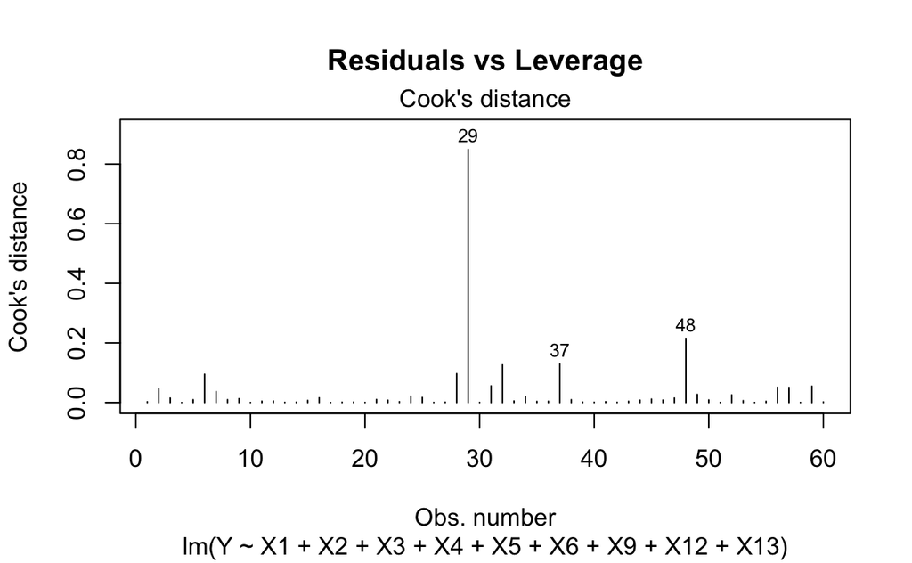

```r
# residuals vs leverage
plot(stepwise_model, which = 4, main = "Residuals vs Leverage")
```

```r
# which = 1 Residuals vs Fitted
# which = 2 Normal Q-Q Plot
# which = 3 Scale-Location (Spread-Location) Plot
# which = 4 Residuals vs Leverage
```

```r
# cook's distance
cooksD <- cooks.distance(stepwise_model)

# influential points with cook's distance > 4/n
n <- nrow(df)  # num of obs
influential_points <- which(cooksD > 4 / n)

# indices of influential points
print(influential_points)
```

```
 6 28 29 32 37 48
 6 28 29 32 37 48
```

```r
# rows of the flagged points
df[influential_points, ]
```

|  | X1 | X2 | X3 | X4 | X5 | X6 | X7 | X8 | X9 | X10 | X11 | X12 | X13 | X14 | X15 | Y |
| --- | --- | --- | --- | --- | --- | --- | --- | --- | --- | --- | --- | --- | --- | --- | --- | --- |
| 6 | 53 | 45 | 80 | 7.7 | 3.45 | 10.2 | 66.8 | 3325 | 38.5 | 43.1 | 25.5 | 30 | 32 | 72 | 54 | 1030.38 |
| 28 | 43 | 32 | 74 | 10.1 | 3.38 | 9.5 | 79.2 | 3214 | 2.9 | 43.7 | 12.0 | 11 | 7 | 32 | 54 | 844.05 |
| 29 | 11 | 53 | 68 | 9.2 | 2.99 | 12.1 | 90.6 | 4700 | 7.8 | 48.9 | 12.3 | 648 | 319 | 130 | 47 | 861.83 |
| 32 | 60 | 67 | 82 | 10.0 | 2.98 | 11.5 | 88.6 | 4657 | 13.5 | 47.3 | 22.4 | 3 | 1 | 1 | 60 | 861.44 |
| 37 | 54 | 54 | 81 | 7.4 | 3.36 | 9.7 | 72.8 | 3172 | 31.4 | 45.5 | 24.2 | 20 | 17 | 1 | 62 | 1113.16 |
| 48 | 18 | 48 | 63 | 9.2 | 2.92 | 12.2 | 87.7 | 4253 | 13.7 | 51.2 | 12.0 | 311 | 171 | 86 | 71 | 911.70 |

## Outlier Detection

Using Cook’s Distance, we identified rows 6, 28, 29, 32, 37, and 48 as influential points. These points exceeded the Cook’s Distance threshold of 4/n, indicating they have a significant impact on the model.

These points should be carefully investigated to determine whether they are valid observations or data entry errors. If valid, they can be retained, but their influence should be noted.

# 5. [40 pts] For the model you chose in Question 3, check the following assumptions using both residual plots and statistical tests (if any). If any of the assumptions is violated, try to remedy the problem. If you cannot resolve the problem, simply state which assumption is violated and what methods you tried. Then, clearly present what the final model is.

### (a) The relationship between the response and the regressors is linear, at least approximately.

### (b) The error term ε has mean zero and constant variance σ2.

### (c) The errors are uncorrelated.

### (d) The errors are normally distributed.

### (e) The regressors are linearly independent.

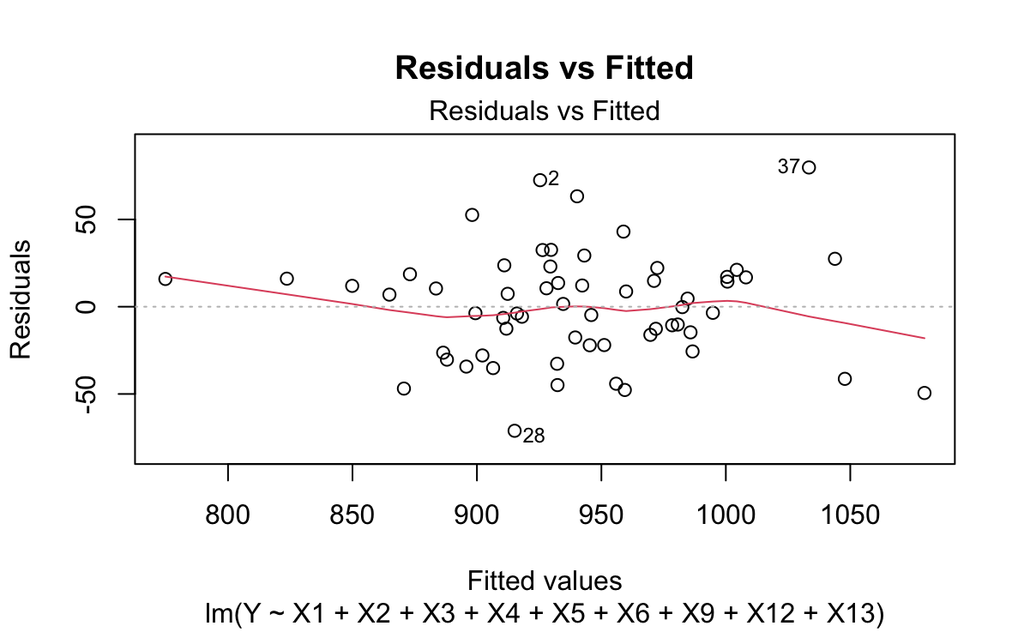

```r
# Assumption 1: Linearity
plot(stepwise_model, which = 1, main = "Residuals vs Fitted")
```

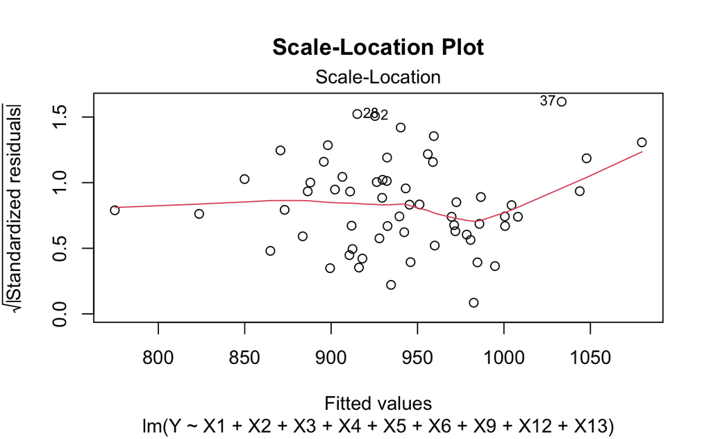

```r
# Assumption 2: Constant Variance
plot(stepwise_model, which = 3, main = "Scale-Location Plot")

# Assumption 3: Uncorrelated Errors
install.packages("lmtest")
library(lmtest)
```

```r
dwtest(stepwise_model)
```

```
    Durbin-Watson test

data:  stepwise_model
DW = 2.1841, p-value = 0.7436
alternative hypothesis: true autocorrelation is greater than 0
```

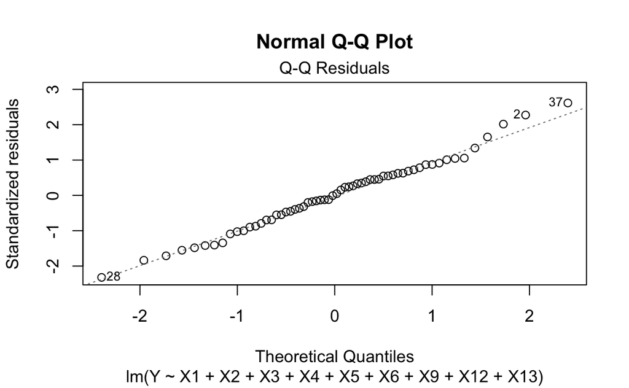

```r
# Assumption 4: Normality of Residuals
plot(stepwise_model, which = 2, main = "Normal Q-Q Plot")
```

```r
shapiro.test(residuals(stepwise_model))
```

```
    Shapiro-Wilk normality test

data:  residuals(stepwise_model)
W = 0.98349, p-value = 0.5923
```

```r
# Assumption 5: Multicollinearity
library(car)
vif(stepwise_model)
```

```
       X1        X2        X3        X4        X5        X6        X9
 3.724589  2.666789  2.359891  5.826631  3.483085  1.898922  3.981753
      X12       X13
45.943057 42.500579
```

## Interpretation of Model Assumptions

To assess the validity of the linear regression model, several diagnostic checks were performed. The Residuals vs Fitted plot indicates that the residuals are randomly scattered around the horizontal line, suggesting that the assumption of linearity is reasonably satisfied. The Scale-Location plot shows a relatively consistent spread of residuals across the fitted values, though a slight upward trend at higher fitted values suggests mild heteroscedasticity. While this indicates minor deviations from constant variance, the effect is not severe enough to undermine the model’s validity.

The Normal Q-Q plot and the Shapiro-Wilk test (W = 0.98349, p-value = 0.5923) confirm that the residuals are approximately normally distributed, with only minor deviations at the tails. The Durbin-Watson test (DW = 2.1841, p-value = 0.7436) shows no significant autocorrelation in the residuals, satisfying this assumption.

Finally, the VIF values reveal high multicollinearity between predictors X12 and X13, with values exceeding 10 (45.94 and 42.50, respectively). To address this, one of these predictors should be removed, or a dimensionality reduction method, such as Principal Component Analysis (PCA), should be applied.

Overall, while the assumptions of linearity, normality, and no autocorrelation are satisfied, minor heteroscedasticity and multicollinearity should be noted and addressed to improve the model’s stability and reliability.